# Enrichment Analysis

Juan R Gonzalez

Bioinformatics Research Group in Epidemiology, Barcelona Institute for Global Health, Spain

juanr.gonzalez@isglobal.org

July, 2019

#### Abstract

Overview of existing methods for enrichment analysis of gene expression data with regard to functional gene sets and pathways. Functionality for differential expression analysis, set- and network-based enrichment analysis, along with visualization and exploration of results. Introduction to concepts for enrichment analysis of genomic regions and regulatory elements.

# 1 Gettig started

This document can be reproduced by using the R code and the data (for illustrating purposes and for the excersises) that are available here: https://github.com/isglobal-brge/post_omic

# 2 Introduction

Test whether known biological functions or processes are over-represented (= enriched) in an experimentally-derived gene list, e.g. a list of differentially expressed (DE) genes. See [Goeman and Buehlmann, 2007](https://doi.org/10.1093/bioinformatics/btm051) for a critical review.

A convenient way to find DE gene sets is by detecting the so-called *functional enrichment* in two steps. First, we search for DE genes. Second, we verify whether these DE genes belong to the gene set in a proportion that exceeds any expectation of finding that number of genes in that gene set by chance alone. A straightforward way to assess this hypothesis consists of applying a hypergeometric test, which in fact corresponds to the one-tailed Fisher’s exact test, following the so-called **urn model**.

A *hypergeometric test* assesses whether a number of successes in a sequence of draws follows a hypergeometric distribution. The *hypergeometric distribution* is a discrete probability distribution that describes the number of successes in a sequence of draws from a finite population without replacement, just as the binomialdistribution describes the number of successes for draws with replacement. In our context this involves the following quantities:

[output not shown]

where:

- $N$ is the total number of genes considered (gene universe).
- $n$ is the number of DE genes.
- $m$ is the number of genes in the gene set.
- $k$ is the number of DE genes in the gene set.

Given these quantities and a random variable $X$ representing the possible outcomes of a hypergeometric process, the probability of getting exactly $k$ genes inside a particular gene set is given by

$$\textrm{Pr}(X=k)=\frac{{m\choose k} {N-m\choose n-k}}{{N\choose n}}$$
Therefore, the probability of getting $k$ or more genes inside a particular gene set, as a hypergeometric random process, is

$$\textrm{Pr}(X >= k)=\sum_{x=k}^n \frac{{m\choose x} {N-m\choose n-x}}{{N\choose n}}$$
This probability is the quantity being used as surrogate for the enrichment of the functional gene set with our list of DE genes, where the lower the value the less likely that we observe those $k$ genes inside the given gene set by pure chance and thus the more enriched that this gene set is enriched with our DE genes.

**Example**: Transcriptomic study, in which 12,671 genes have been tested for differential expression between two sample conditions and 529 genes were found DE. Among the DE genes, 28 are annotated to a specific functional gene set (or pathway), which contains in total 170 genes. This setup corresponds to a 2x2 contingency table,

```r
deTable <-  matrix(c(28, 142, 501, 12000),
            nrow = 2,
            dimnames = list(DE=c("yes","no"),
                            GeneSet=c("in","out")))

deTable
```

```
     GeneSet
DE     in   out
  yes  28   501
  no  142 12000
```

where the overlap of 28 genes can be assessed based on the hypergeometric distribution. This corresponds to a one-sided version of Fisher’s exact test, yielding here a significant enrichment.

```r
fisher.test(deTable, alternative = "greater")
```

```
    Fisher's Exact Test for Count Data

data:  deTable
p-value = 4.088e-10
alternative hypothesis: true odds ratio is greater than 1
95 percent confidence interval:
 3.226736      Inf
sample estimates:
odds ratio
  4.721744
```

This basic principle is at the foundation of major public and commercial enrichment tools such as [DAVID](https://david.ncifcrf.gov/) and [Pathway Studio](https://www.pathwaystudio.com).

Although gene set enrichment methods have been primarily developed and applied on transcriptomic data, they have recently been modified, extended and applied also in other fields of genomic and biomedical research. This includes novel approaches for functional enrichment analysis of proteomic and metabolomic data as well as genomic regions and disease phenotypes, [Lavallee and Yates, 2016](https://doi.org/10.1002/0471250953.bi1328s53), [Chagoyen et al., 2016](https://doi.org/10.1007/978-1-4939-3572-7_20), [McLean et al., 2010](https://doi.org/10.1038/nbt.1630), [Ried et al., 2012](https://doi.org/10.1002/gepi.21617).

**EXERCISE**: Library `tweeDEseqCountData` contains data corresponding to an RNA-seq experiment described in Pickrell et al. (2010). Data correspond to lymphoblastoid cell lines about 69 non-related Nigerian individuals. This information as well as phenotypic data is available as an object of class `eSet` called `pickrell.eset` that can be loaded after typing:

```
data(pickrell)
```

1. Use limma-voom method to detect those genes that are differentially expressed (DE) between males and females (variale `gender`).
2. Select those genes that are DE at 5% FDR with a minimum fold-change of 1.5
3. Create a gene set of sex-expecific genes by

```
geneUniverse <- featureNames(pickrell.eset)
geneSex <- unique(intersect(geneUniverse,
                  c(msYgenes, XiEgenes)))
```

and test whether the list of DE genes is enriched in that gene set.

# 3 Gene expression-based enrichment analysis

This methodology can be extended to the analysis of multiple gene sets available in different databases such as GO or KEGG among others. Next sections illustrate how to perform such analyses using different BioC packages.

## 3.1 A primer on terminology, existing methods & statistical theory

**Gene sets, pathways & regulatory networks**

Gene sets are simple lists of usually functionally related genes without further specification of relationships between genes.

Pathways can be interpreted as specific gene sets, typically representing a group of genes that work together in a biological process. Pathways are commonly divided in metabolic and signaling pathways. Metabolic pathways such as glycolysis represent biochemical substrate conversions by specific enzymes. Signaling pathways such as the MAPK signaling pathway describe signal transduction cascades from receptor proteins to transcription factors, resulting in activation or inhibition of specific target genes.

Gene regulatory networks describe the interplay and effects of regulatory factors (such as transcription factors and microRNAs) on the expression of their target genes.

**Resources**

[GO](http://www.geneontology.org), [KEGG](http://www.genome.jp/kegg) and [MSigDB](http://software.broadinstitute.org/gsea/msigdb/collections.jsp) annotations are most frequently used for the enrichment analysis of functional gene sets. Despite an increasing number of gene set and pathway databases, they are typically the first choice due to their long-standing curation and availability for a wide range of species.

*GO*: The Gene Ontology (GO) consists of three major sub-ontologies that classify gene products according to molecular function (MF), biological process (BP) and cellular component (CC). Each ontology consists of GO terms that define MFs, BPs or CCs to which specific genes are annotated. The terms are organized in a directed acyclic graph, where edges between the terms represent relationships of different types. They relate the terms according to a parent-child scheme, i.e. parent terms denote more general entities, whereas child terms represent more specific entities.

*KEGG*: The Kyoto Encyclopedia of Genes and Genomes (KEGG) is a collection of manually drawn pathway maps representing molecular interaction and reaction networks. These pathways cover a wide range of biochemical processes that can be divided in 7 broad categories: metabolism, genetic and environmental information processing, cellular processes, organismal systems, human diseases, and drug development. Metabolism and drug development pathways differ from pathways of the other 5 categories by illustrating reactions between chemical compounds. Pathways of the other 5 categories illustrate molecular interactions between genes and gene products.

*MSigDB*: Molecular Signatures Database (MSigDB) are divided into 8 major collections, and several sub-collections. These include:

- *H: hallmark gene sets*: Hallmark gene sets summarize and represent specific well-defined biological states or processes and display coherent expression.
- *C1: positional gene sets*: Gene sets corresponding to each human chromosome and each cytogenetic band that has at least one gene.
- *C2: curated gene sets*: Gene sets curated from various sources such as online pathway databases, the biomedical literature, and knowledge of domain experts. It contains 5 sub-collections.
- *C3 motif gene sets*: Gene sets representing potential targets of regulation by transcription factors or microRNAs. It has 2 sub-collections.
- *C4 computational gene sets*: Computational gene sets defined by mining large collections of cancer-oriented microarray data. It has 4 sub-collections.
- *C5 GO gene sets*: Gene sets that contain genes annotated by the same GO term. The C5 collection is divided into three sub-collections based on GO ontologies: BP, CC, and MF.
- *C6 oncogenic signatures*: Gene sets that represent signatures of cellular pathways which are often dis-regulated in cancer.
- *C7 inmunologic signatures*: Gene sets that represent cell states and perturbations within the immune system.

**Statistical approaches**

The two predominantly used enrichment methods are:

- Overrepresentation analysis (ORA), testing whether a gene set contains disproportional many genes of significant expression change, based on the procedure outlined in the first section.
- Gene set enrichment analysis (GSEA), testing whether genes of a gene set accumulate at the top or bottom of the full gene vector ordered by direction and magnitude of expression change [Subramanian et al., 2005](https://doi.org/10.1073/pnas.0506580102). However, the term *gene set enrichment analysis* nowadays subsumes a general strategy implemented by a wide range of methods [Huang et al., 2009](https://doi.org/10.1093/nar/gkn923). Those methods have in common the same goal, although approach and statistical model can vary substantially [Goeman and Buehlmann, 2007](https://doi.org/10.1093/bioinformatics/btm051), [Khatri et al., 2012](https://doi.org/10.1371/journal.pcbi.1002375).

To better distinguish from the specific method, some authors use the term *gene set analysis* to denote the general strategy. However, there is also a specific method from [Efron and Tibshirani, 2007](https://doi.org/10.1214/07-AOAS101) of this name.

Goeman and Buehlmann further raise several critical issues concerning the 2x2 ORA:

- rather arbitrary classification of genes in DE / not DE
- based on gene sampling, although sampling of subjects is appropriate
- unrealistic independence assumption between genes, resulting in highly anti-conservative *p*-values

With regard to these statistical concerns, GSEA is considered superior:

- takes all measured genes into account
- subject sampling via permutation of class labels
- the incorporated permutation procedure implicitly accounts for correlations between genes

However, the simplicity and general applicability of ORA is unmet by subsequent methods improving on these issues. For instance, GSEA requires the expression data as input, which is not available for gene lists derived from other experiment types. On the other hand, the involved sample permutation procedure has been proven inaccurate and time-consuming [Efron and Tibshirani, 2007](https://doi.org/10.1214/07-AOAS101), [Phipson and Smyth, 2010](https://doi.org/10.2202/1544-6115.1585), [Larson and Owen, 2015](https://doi.org/10.1186/s12859-015-0571-7).

[Khatri et al., 2012](https://doi.org/10.1371/journal.pcbi.1002375) have taken a slightly different approach by classifying methods along the timeline of development into three generations:

1. Generation: ORA methods based on the 2x2 contingency table test,
2. Generation: functional class scoring (FCS) methods such as GSEA, which compute gene set (= functional class) scores by summarizing per-gene DE statistics,
3. Generation: topology-based methods, explicitly taking into account interactions between genes as defined in signaling pathways and gene regulatory networks ([Geistlinger et al., 2011](https://doi.org/10.1093/bioinformatics/btr228) for an example).

Although topology-based (also: network-based) methods appear to be most realistic, their straightforward application can be impaired by features that are not-detectable on the transcriptional level (such as protein-protein interactions) and insufficient network knowledge [Geistlinger et al., 2013](https://doi.org/10.1093/nar/gkt631), [Bayerlova et al., 2015](https://doi.org/10.1186/s12859-015-0751-5).

Given the individual benefits and limitations of existing methods, cautious interpretation of results is required to derive valid conclusions. Whereas no single method is best suited for all application scenarios, applying multiple methods can be beneficial. This has been shown to filter out spurious hits of individual methods, thereby reducing the outcome to gene sets accumulating evidence from different methods [Geistlinger et al., 2016](https://doi.org/10.1186/s12859-016-0884-1), [Alhamdoosh et al., 2017](https://doi.org/10.1093/bioinformatics/btw623).

## 3.2 Basic analysis using `GOstats`

```r
library(airway)
data(airway)
table(airway$dex)
```

```
  trt untrt
    4     4
```

Then, let us analyzed the RNA-seq count data using `edgeR` that uses generalized linear models (negative binomial) (`DESeq2`, `voom` or any other method could be used instead). NOTE that we avoid normalization step which is normally required (`DESeq2` incorporates this step in its pipeline).

```r
library(edgeR)
airCounts <- assay(airway)
group <- airway$dex
d <- DGEList(counts=airCounts, group=group)
design <- model.matrix( ~ group)
d <- estimateDisp(d, design)
d$common.dispersion
```

```
[1] 0.06582533
```

```r
# LRT test
fit <- glmFit(d, design)  # glmFit is similar to edgeR::exactTest()
lrt <- glmLRT(fit,coef=2) #       but faster
topTags(lrt)
```

```
Coefficient:  groupuntrt
                     logFC   logCPM       LR       PValue          FDR
ENSG00000152583  -4.525025 5.510630 343.0933 1.352765e-76 8.671497e-72
ENSG00000120129  -2.869085 7.282149 190.6490 2.294409e-43 7.353809e-39
ENSG00000179094  -3.102115 5.156978 172.0453 2.645262e-39 5.652219e-35
ENSG00000189221  -3.224297 6.742215 170.3724 6.135284e-39 9.832099e-35
ENSG00000109906  -7.061824 4.133786 160.2188 1.013543e-36 1.299402e-32
ENSG00000101347  -3.769000 9.171373 154.6047 1.708396e-35 1.825193e-31
ENSG00000179593 -10.058544 1.630926 150.7284 1.201571e-34 1.100330e-30
ENSG00000178695   2.577297 6.985703 149.1578 2.648855e-34 2.122461e-30
ENSG00000162614  -1.949329 7.952323 138.2899 6.297761e-32 4.485545e-28
ENSG00000096060  -3.858601 6.870780 137.2929 1.040487e-31 6.669733e-28
```

We call DE genes with a minimum 2-fold change of expression at a maximum FDR of 1%:

```r
tt <- topTags(lrt, n=Inf)
mask <- tt$table$FDR < 0.01 &
        abs(tt$table$logFC) > log2(2)
deGenes <- rownames(tt$table[mask, ])
head(deGenes)
```

```
[1] "ENSG00000152583" "ENSG00000120129" "ENSG00000179094" "ENSG00000189221" "ENSG00000109906" "ENSG00000101347"
```

```r
length(deGenes)
```

```
[1] 641
```

The gene univese is obtained by:

```r
geneUniverse <- rownames(tt$table)
length(geneUniverse)
```

```
[1] 64102
```

In order to asses functional enrichment, both DE gene list and gene universe must be annotated in Entrez IDs:

```r
library(org.Hs.eg.db)
deGenes <- unlist(mget(deGenes, envir=org.Hs.egENSEMBL2EG,
                       ifnotfound = NA))

geneUniverse <- unlist(mget(geneUniverse, envir=org.Hs.egENSEMBL2EG,
                       ifnotfound = NA))
```

Now, the enrichment analysis for GO is performed by

```r
library(GOstats)
params <- new("GOHyperGParams", geneIds=deGenes,
              universeGeneIds=geneUniverse,
              annotation="org.Hs.eg.db", ontology="BP",
              pvalueCutoff=0.05, conditional=FALSE,
              testDirection="over")

hgOver <- hyperGTest(params)
hgOver
```

```
Gene to GO BP  test for over-representation
5909 GO BP ids tested (1403 have p < 0.05)
Selected gene set size: 514
    Gene universe size: 17033
    Annotation package: org.Hs.eg
```

The table can be generated by

```r
head(summary(hgOver))
```

```
      GOBPID       Pvalue OddsRatio  ExpCount Count Size                                               Term
1 GO:0051239 5.923181e-13  2.106943  87.42195   152 2897     regulation of multicellular organismal process
2 GO:0051094 1.531846e-11  2.467166  39.10902    84 1296       positive regulation of developmental process
3 GO:2000026 2.970022e-11  2.184166  58.57301   110 1941 regulation of multicellular organismal development
4 GO:0048518 3.257549e-11  1.819219 170.13632   241 5638          positive regulation of biological process
5 GO:0009653 4.892855e-11  2.026982  78.58017   135 2604                 anatomical structure morphogenesis
6 GO:0050793 8.517164e-11  2.029100  75.20038   130 2492                regulation of developmental process
```

We can alos explore the results by generating an html report:

```r
htmlReport(hgOver, file="goBPuncond.html")
```

The KEGG enrichment is performed by:

```r
library(KEGG.db)
params.kegg <- new("KEGGHyperGParams", geneIds=deGenes,
                   universeGeneIds=geneUniverse,
                   annotation="org.Hs.eg.db",
                   pvalueCutoff=0.05,
                   testDirection="over")

hgOver.kegg <- hyperGTest(params.kegg)
head(summary(hgOver.kegg))
```

```
  KEGGID       Pvalue OddsRatio  ExpCount Count Size                                        Term
1  04666 0.0005039238  3.694444 3.3838788    11   93            Fc gamma R-mediated phagocytosis
2  04350 0.0008595601  3.708407 3.0564067    10   84                  TGF-beta signaling pathway
3  00750 0.0008756124 26.854369 0.2183148     3    6                       Vitamin B6 metabolism
4  00250 0.0008854239  6.262599 1.1643454     6   32 Alanine, aspartate and glutamate metabolism
5  05144 0.0022637531  4.324595 1.8556755     7   51                                     Malaria
6  00330 0.0031583118  4.046345 1.9648329     7   54             Arginine and proline metabolism
```

## 3.3 Analysis using `clusterProfiler`

clusterProfiler performs statistical analysis and visualization of functional profiles for genes and gene clusters. It includes GO, KEEG and a general function to perform ORA for any database such as MSigDB or [DisGeNET](http://www.disgenet.org/) among others.

```r
library(clusterProfiler)
ans.go <- enrichGO(gene = deGenes, ont = "BP",
                   OrgDb ="org.Hs.eg.db",
                   readable=TRUE,
                   pvalueCutoff = 0.05)
tab.go <- as.data.frame(ans.go)
tab.go<- subset(tab.go, Count>5)
tab.go[1:5, 1:6]
```

```
                   ID                                       Description GeneRatio   BgRatio       pvalue    p.adjust
GO:0007411 GO:0007411                                     axon guidance    22/514 248/17653 3.770863e-06 0.008820586
GO:0097485 GO:0097485                        neuron projection guidance    22/514 250/17653 4.297356e-06 0.008820586
GO:0030198 GO:0030198                 extracellular matrix organization    26/514 341/17653 8.262844e-06 0.008820586
GO:0032963 GO:0032963                        collagen metabolic process    14/514 124/17653 1.528500e-05 0.010449642
GO:0051962 GO:0051962 positive regulation of nervous system development    32/514 493/17653 2.148948e-05 0.010449642
```

```r
ans.kegg <- enrichKEGG(gene = deGenes,
                       organism = 'hsa',
                       pvalueCutoff = 0.05)
tab.kegg <- as.data.frame(ans.kegg)
tab.kegg<- subset(tab.kegg, Count>5)
tab.kegg[1:5, 1:6]
```

```
               ID                                          Description GeneRatio  BgRatio       pvalue    p.adjust
hsa04360 hsa04360                                        Axon guidance    19/263 181/7867 8.915744e-06 0.002460745
hsa04213 hsa04213      Longevity regulating pathway - multiple species    10/263  62/7867 3.403851e-05 0.004697314
hsa04926 hsa04926                            Relaxin signaling pathway    14/263 130/7867 1.047098e-04 0.006819867
hsa04933 hsa04933 AGE-RAGE signaling pathway in diabetic complications    12/263 100/7867 1.159686e-04 0.006819867
hsa04068 hsa04068                               FoxO signaling pathway    14/263 132/7867 1.235483e-04 0.006819867
```

For external databases such as DisGeNET or MSigDB collections, databases must be imported into R. This is how DisGeNET is imported into R

```r
gda <- read.delim("data/curated_gene_disease_associations.tsv.gz")
disease2gene <- gda[, c("diseaseId", "geneId")]
disease2name <- gda[, c("diseaseId", "diseaseName")]
```

Then, the enrichment is perform using `enricher` function:

```r
ans.dis <- enricher(deGenes, TERM2GENE=disease2gene,
                    TERM2NAME=disease2name)
tab.dis <- as.data.frame(ans.dis)
tab.dis<- subset(tab.dis, Count>5)
tab.dis[,1:6]
```

```
               ID         Description GeneRatio  BgRatio       pvalue     p.adjust
C0014175 C0014175       Endometriosis    23/317 156/8948 5.273741e-09 6.934969e-06
C0151744 C0151744 Myocardial Ischemia    23/317 171/8948 3.141889e-08 2.065792e-05
C0525045 C0525045      Mood Disorders    20/317 187/8948 9.658646e-06 4.233706e-03
C3495559 C3495559  Juvenile arthritis    15/317 130/8948 5.280220e-05 1.735872e-02
C0011570 C0011570   Mental Depression    22/317 260/8948 1.327260e-04 3.490695e-02
C0018800 C0018800        Cardiomegaly    13/317 115/8948 2.042831e-04 4.477205e-02
```

This is the R code for transcription factors which is one of the sub-collection of C3 available at [MSigDb](http://software.broadinstitute.org/gsea/msigdb) for additional gene set collections.

```r
c3.tf <- read.gmt("c:/Juan/CREAL/HELIX/pathways/GSEA/c3.tft.v6.2.entrez.gmt")

ans.tf <- enricher(deGenes, TERM2GENE=c3.tf)
tab.tf <- as.data.frame(ans.tf)
tab.tf<- subset(tab.tf, Count>5)
tab.tf[1:5,1:5]
```

```
                                 ID       Description GeneRatio   BgRatio       pvalue
RP58_01                     RP58_01           RP58_01    22/429 207/12774 1.783045e-06
SRF_C                         SRF_C             SRF_C    21/429 211/12774 8.635255e-06
SRF_Q6                       SRF_Q6            SRF_Q6    22/429 241/12774 2.089380e-05
AAANWWTGC_UNKNOWN AAANWWTGC_UNKNOWN AAANWWTGC_UNKNOWN    19/429 193/12774 2.692390e-05
HNF3_Q6                     HNF3_Q6           HNF3_Q6    18/429 189/12774 6.755471e-05
```

## 3.4 Visualization

All analyses performed with `clusterProfiler` can be visualize by different plots:

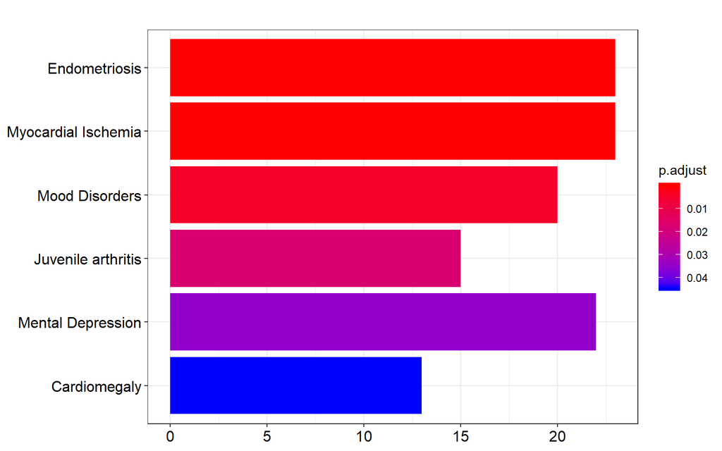

```r
library(enrichplot)
p1 <- barplot(ans.dis, showCategory=10)
p1
```

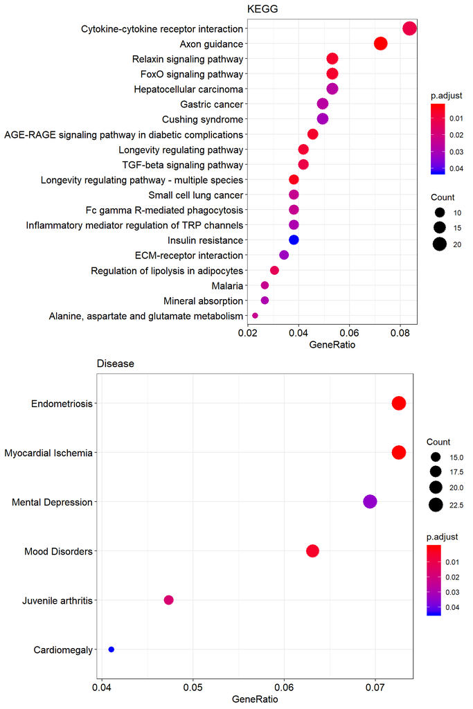

```r
p2 <- dotplot(ans.kegg, showCategory=20) + ggtitle("KEGG")
p3 <- dotplot(ans.dis, showCategory=20) + ggtitle("Disease")
plot_grid(p2, p3, nrow=2)
```

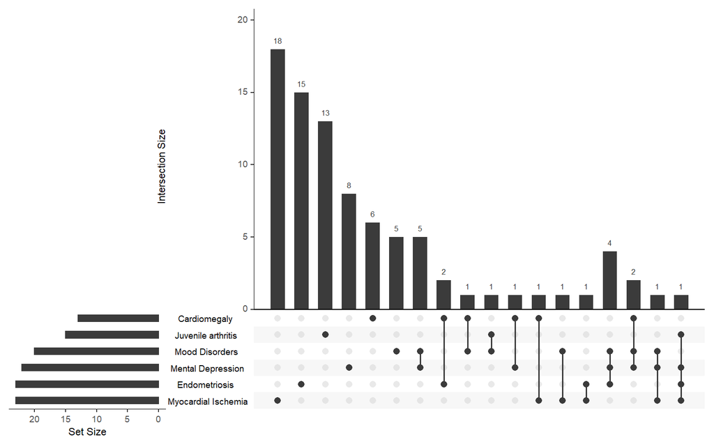

```r
p4 <- upsetplot(ans.dis)
p4
```

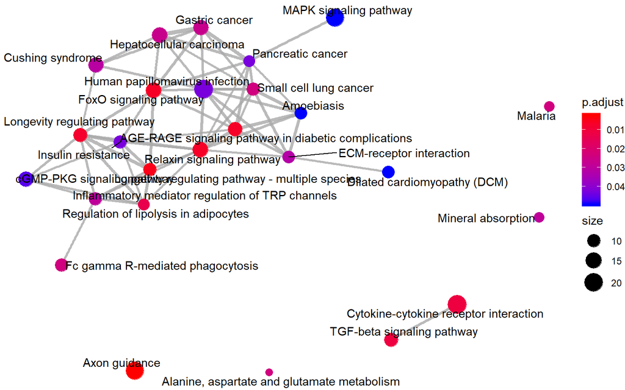

```r
p5 <- emapplot(ans.kegg)
p5
```

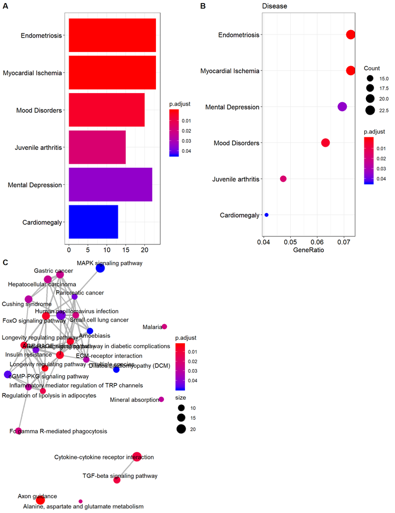

```r
cowplot::plot_grid(p1, p3, p5, ncol=2, labels=LETTERS[1:3])
```

# 4 Genomic region enrichment analysis

Microarrays and next-generation sequencing are also widely applied for large-scale detection of variable and regulatory genomic regions, e.g. single nucleotide polymorphisms, copy number variations, and transcription factor binding sites. Such experimentally-derived genomic region sets are raising similar questions regarding functional enrichment as in gene expression data analysis. Of particular interest is thereby whether experimentally-derived regions overlap more (enrichment) or less (depletion) than expected by chance with regions representing known functional features such as genes or promoters.

The `regioneR` package implements a general framework for testing overlaps of genomic regions based on permutation sampling. This allows to repeatedly sample random regions from the genome, matching size and chromosomal distribution of the region set under study. By recomputing the overlap with the functional features in each permutation, statistical significance of the observed overlap can be assessed. To demonstrate the basic functionality of the package, we consider the analysis of copy number variants (CNV).

Let us assume, we want to assess the overlap between the significant CNV regions obtained after comparing normal vs tumor samples from [TCGA](https://www.cancer.gov/about-nci/organization/ccg/research/structural-genomics/tcga) and protein-coding regions. We now recall the results we obtained in the association analysis

```r
load("data/brcaSigCNV.Rdata")
brca.gr.sig
```

```
GRanges object with 7362 ranges and 3 metadata columns:
         seqnames              ranges strand |   counts               pvalue                   BH
            <Rle>           <IRanges>  <Rle> | <matrix>            <numeric>            <numeric>
     [1]     chr1 149898951-150333087      * |     1:30 9.17196804835805e-07 6.85696840142296e-06
     [2]     chr1 150335347-151170789      * |     0:30 4.02900812259604e-08 3.69842635940347e-07
     [3]     chr1 154984468-155005476      * |     0:21 6.60494300658908e-06 4.05859140379805e-05
     [4]     chr1 155006954-155050185      * |     0:22 3.64039791063025e-06 2.34223634083979e-05
     [5]    chr11   60943071-61361689      * |     0:16 0.000138664831551331 0.000654493148010495
     ...      ...                 ...    ... .      ...                  ...                  ...
  [7358]    chr11   69559601-69650887      * |     0:66 2.94813576696704e-17 9.70149048297054e-16
  [7359]    chr11   70695866-71002410      * |     1:53 1.24305369365935e-12 2.43117126979776e-11
  [7360]    chr11   73552530-73878688      * |     0:22 3.64039791063025e-06 2.34223634083979e-05
  [7361]    chr11   74853813-74901601      * |     0:21 6.60494300658908e-06 4.05859140379805e-05
  [7362]    chr16      653459-2025678      * |     1:16  0.00101824759029954  0.00399167866271459
  -------
  seqinfo: 23 sequences from an unspecified genome; no seqlengths
```

To obtain the location of protein-coding genes, we query available Human annotation from Ensembl

```r
library(AnnotationHub)
ah <- AnnotationHub()
ahDb <- query(ah, pattern = c("Homo sapiens", "EnsDb"))
ahDb
```

```r
ahEdb <- ahDb[["AH60977"]]
hg.genes <- genes(ahEdb)
```

We then need to verify that the `seqlevels` annotation of both `GenomicRanges` are the same:

```r
seqnames(hg.genes)
```

```
factor-Rle of length 65256 with 423 runs
  Lengths:                          5349                          2236 ...                           518
  Values :                          chr1                         chr10 ...                          chrY
Levels(423): chr1 chr10 chr11 chr12 chr13 chr14 chr15 ... chrLRG_721 chrLRG_741 chrLRG_763 chrLRG_93 chrMT chrX chrY
```

```r
seqnames(brca.gr.sig)
```

```
factor-Rle of length 7362 with 1548 runs
  Lengths:     4     9     3    11     1    45     1     1    16 ...     1     1     9    21     1     2     8     1
  Values :  chr1 chr11 chr12 chr20 chr11 chr17 chr20  chr5  chr8 ...  chr8 chr16  chr8 chr11 chr17 chr10 chr11 chr16
Levels(23): chr1 chr2 chr3 chr10 chr14 chr4 chr11 chr12 chr20 ... chr15 chr17 chrX chr8 chr16 chr19 chr13 chr22 chr18
```

otherwise we need to re-assign the `seqlevels`

```r
seqlevels(hg.genes) <- paste0("chr", seqlevels(hg.genes))
```

Let us run the enrichment in chromosome 1:

```r
sel.protein <- hg.genes[seqnames(hg.genes)%in%c("chr1")]
sel.protein <- sel.protein[sel.protein$gene_biotype ==
                             "protein_coding"]
sel.cnvs <- brca.gr.sig[seqnames(brca.gr.sig)%in%c("chr1")]
length(sel.cnvs)
```

```
[1] 234
```

We then apply an overlap permutation test with 100 permutations (`ntimes=100`), while maintaining chromosomal distribution of the CNV region set (`per.chromosome=TRUE`). Setting the option `count.once=TRUE` counts an overlapping CNV region only once. To randomly sample regions from the entire genome no masking is required (`mask=NA`) and to draw robust conclusions a minimum of 1000 permutations should be performed

```r
library(regioneR)
library(BSgenome.Hsapiens.UCSC.hg19.masked)
res.prot <- overlapPermTest(A=sel.cnvs, B=sel.protein,
                            mask=NA, genome="hg19",
                            ntimes=100,
                            per.chromosome=TRUE,
                            count.once=TRUE)
res.prot
```

```
$numOverlaps
P-value: 0.0099009900990099
Z-score: 7.7826
Number of iterations: 100
Alternative: greater
Evaluation of the original region set: 220
Evaluation function: numOverlaps
Randomization function: randomizeRegions

attr(,"class")
[1] "permTestResultsList"
```

The permutation $P$-value indicates a statistically significant overlaps of CNVs with protein coding regions. From 234 CNVs, 220 overlap with at least one protein coding gene. We can also repeat the analysis for promoters from UCSC defined as -2000 to +200 base pairs to the TSS according to the genome assembly hg19. Analyzing chromosome 1

```r
file.prom <- "http://gattaca.imppc.org/regioner/data/UCSC.promoters.hg19.bed"
promoters <- toGRanges(file.prom)
sel.prom <- promoters[seqnames(promoters) %in% c("chr1")]
```

we obtain

```r
res.prom <- overlapPermTest(sel.cnvs, sel.prom,
                            ntimes=100, genome="hg19",
                            count.once=TRUE)
res.prom
```

```
$numOverlaps
P-value: 0.0099009900990099
Z-score: 58.545
Number of iterations: 100
Alternative: greater
Evaluation of the original region set: 184
Evaluation function: numOverlaps
Randomization function: randomizeRegions

attr(,"class")
[1] "permTestResultsList"
```

We also observe significant overlap of CNVs in regions with promoters. Notice that the function `permTest` allows user-defined functions for randomizing control and for evaluating additional genomic measures.

Note #1: The function `regioneR::permTest` allows to incorporate user-defined functions for randomizing regions and evaluating additional measures of overlap such as total genomic size in bp.

Note #2: The *LOLA* package implements a genomic region ORA, which assesses genomic region overlap based on the hypergeometric distribution using a library of pre-defined functional region sets.

**EXERCISE**: The file `data_exercises/GSE18123.Rdata` contains data corresponing to the GEO accesion number GSE18123. This dataset was used to test whether peripheral blood gene expression profiles could be used as a molecular diagnostic tool for distinguishing children with Autistic Spectrum Disorder (ASD) from controls by performing peripheral blood gene expression profiling on 170 patients with ASD and 115 controls collected from Boston area hospitals.

1. Determine those genes that are differentially expressed between CONTROLs and AUTISM (variable `group`).
2. Perform an enrichment analysis of GO, KEGG and DisGeNET databases using `clusterProfiler`.
3. Investigate whether the DE genes are enriched in protein-coding genes.